# Proyección de Inflación en Bolivia

Modelo ARIMAX — Tipo de Cambio Digital como Regresor Exógeno

Análisis Econométrico

16 de julio de 2026

# 1 Motivación

De la batería de modelos ya construida (ARIMA M1/M2 directo y logarítmico, SARIMA puro, SARIMA + intervenciones, y SARIMAX estacional con tipo de cambio), falta el eslabón **no estacional** que aísla el efecto del tipo de cambio digital sobre el mismo ARIMA(p,d,q) log(IPC) (“M2”) que ya es la especificación base del proyecto. Este documento estima esa pieza — **ARIMAX(p,d,q) sobre log(IPC) con el TC digital como regresor exógeno** — y la compara contra el ARIMA base (sin exógena) mediante backtesting, que es el criterio que decide cuál de los dos se usa para el pronóstico final.

# 2 Datos: IPC y Tipo de Cambio Digital

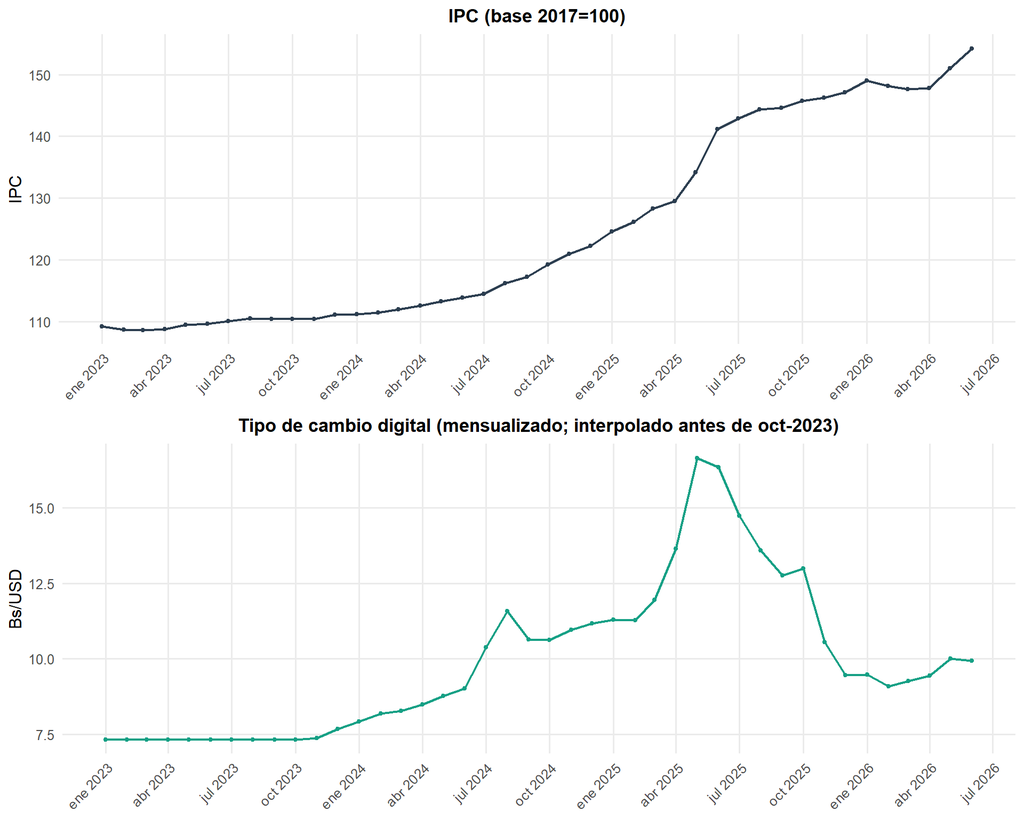

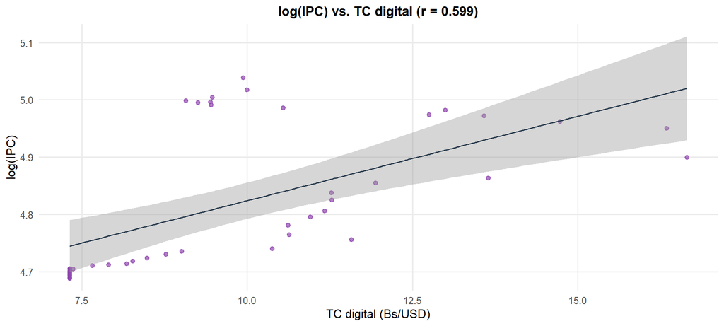

> Correlación en niveles entre log(IPC) y TC digital: **r = 0.599**. Una correlación alta en niveles no implica que el tipo de cambio explique la *dinámica* de corto plazo de la inflación — de ahí la necesidad de validar con backtesting, no solo con ajuste dentro de muestra.

# 3 Identificación y Estacionariedad

Pruebas de raíz unitaria

| Prueba | Serie | Estadístico | p-valor | Conclusión |
| --- | --- | --- | --- | --- |
| **log(IPC)** |  |  |  |  |
| ADF | log(IPC) | -1.9622 | 0.5885 | No estac. |
| Phillips-Perron | log(IPC) | -4.5192 | 0.8478 | No estac. |
| KPSS | log(IPC) | 1.0844 | 0.0100 | No estac. |
| Zivot-Andrews | log(IPC) | -3.7966 | 0.1000 | No estac. |
| **Δlog(IPC)** |  |  |  |  |
| ADF | Δlog(IPC) | -2.2554 | 0.4731 | No estac. |
| Phillips-Perron | Δlog(IPC) | -20.2576 | 0.0371 | Estac. |
| KPSS | Δlog(IPC) | 0.3903 | 0.0813 | Estac. |
| Zivot-Andrews | Δlog(IPC) | -4.5719 | 0.1000 | No estac. |
| **TC digital (regresor)** |  |  |  |  |
| ADF | TC digital | -1.5724 | 0.7422 | No estac. |
| KPSS | TC digital | 0.6199 | 0.0208 | No estac. |

> Zivot-Andrews (quiebre en intercepto): quiebre detectado en **abr 2025** (log(IPC)) y **ago 2025** (Δlog(IPC)). El TC digital muestra su propia dinámica no estacionaria (propia de un tipo de cambio paralelo/cripto en un contexto de escasez de dólares); esto se maneja como regresión con errores ARMA (forecast::Arima con `xreg`), no como una relación de cointegración formal — el criterio de validación es el desempeño fuera de muestra (sección de Backtesting).

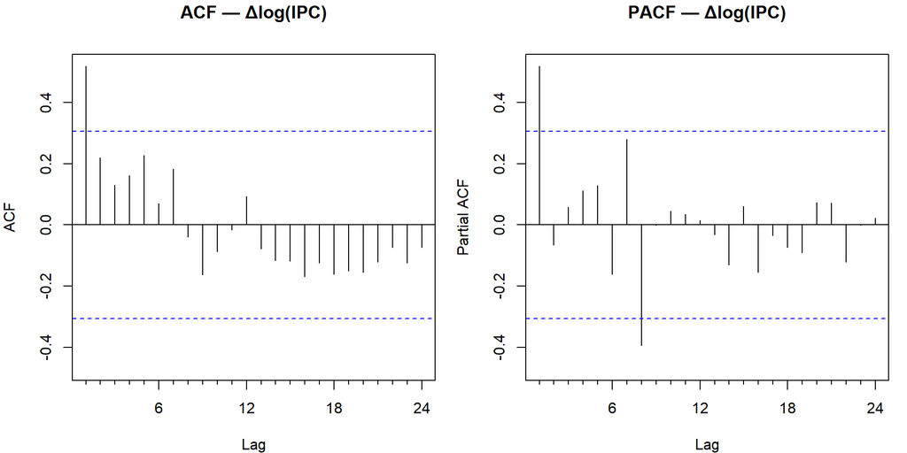

# 4 Estimación y Selección — ARIMA base vs. ARIMAX

Ambas grillas recorren $p,q \in [0,4]$, $d \in \{0,1\}$ sobre **log(IPC)**; la única diferencia es la presencia del regresor `TC_dig` (TC digital). Mismo scoring compuesto que el resto del proyecto: RMSE + MAPE + promedio(AICc, BIC, HQ) + 0.3 × Complejidad + penalizaciones por Ljung-Box y raíces inversas.

## 4.1 ARIMA base (sin exógena)

ARIMA base — Top 15 de 48 modelos (log IPC, sin regresor)

| Modelo | d | AICc | BIC | HQ | RMSE | MAPE | LB12(p) | Raices | Score |
| --- | --- | --- | --- | --- | --- | --- | --- | --- | --- |
| ARIMA(1,1,0) | 1 | -261.96 | -258.85 | -261.03 | 0.00924 | 0.122 | 0.0599 | OK | -1.598 |
| ARIMA(1,1,1) | 1 | -259.88 | -255.39 | -258.66 | 0.00921 | 0.121 | 0.0641 | OK | -1.370 |
| ARIMA(2,1,0) | 1 | -259.77 | -255.28 | -258.55 | 0.00922 | 0.120 | 0.0556 | OK | -1.369 |
| ARIMA(0,1,2) | 1 | -256.37 | -251.88 | -255.15 | 0.00960 | 0.133 | 0.0603 | OK | -1.145 |
| ARIMA(2,1,2) | 1 | -259.15 | -252.29 | -257.74 | 0.00865 | 0.121 | 0.0754 | OK | -1.077 |
| ARIMA(0,1,3) | 1 | -256.31 | -250.57 | -254.92 | 0.00928 | 0.128 | 0.0657 | OK | -1.040 |
| ARIMA(3,1,1) | 1 | -258.06 | -251.21 | -256.66 | 0.00876 | 0.122 | 0.0583 | OK | -1.022 |
| ARIMA(3,1,2) | 1 | -257.45 | -249.64 | -256.18 | 0.00846 | 0.116 | 0.0623 | OK | -0.911 |
| ARIMA(2,1,3) | 1 | -257.07 | -249.26 | -255.80 | 0.00855 | 0.118 | 0.0511 | OK | -0.879 |
| ARIMA(3,1,4) | 1 | -259.33 | -250.13 | -258.84 | 0.00754 | 0.104 | 0.3692 | OK | -0.827 |
| ARIMA(1,1,4) | 1 | -255.62 | -247.80 | -254.34 | 0.00873 | 0.117 | 0.0664 | OK | -0.816 |
| ARIMA(0,1,4) | 1 | -252.88 | -246.02 | -251.47 | 0.00929 | 0.129 | 0.1598 | OK | -0.757 |
| ARIMA(2,1,4) | 1 | -255.34 | -246.74 | -254.36 | 0.00832 | 0.113 | 0.0500 | OK | -0.714 |
| ARIMA(4,1,2) | 1 | -253.40 | -244.80 | -252.42 | 0.00841 | 0.109 | 0.0525 | OK | -0.666 |
| ARIMA(4,1,3) | 1 | -255.82 | -246.62 | -255.33 | 0.00772 | 0.110 | 0.0568 | OK | -0.660 |

> **Ganador:** ARIMA(1,1,0) (Score = -1.598)

## 4.2 ARIMAX (+ TC digital)

ARIMAX — Top 15 de 49 modelos (log IPC + TC digital)

| Modelo | d | AICc | BIC | HQ | RMSE | MAPE | LB12(p) | Raices | Score |
| --- | --- | --- | --- | --- | --- | --- | --- | --- | --- |
| ARIMA(1,1,0) | 1 | -261.99 | -257.50 | -260.77 | 0.00898 | 0.118 | 0.1417 | OK | -1.618 |
| ARIMA(2,1,0) | 1 | -259.57 | -253.82 | -258.18 | 0.00897 | 0.117 | 0.1040 | OK | -1.371 |
| ARIMA(1,1,1) | 1 | -259.59 | -253.85 | -258.21 | 0.00897 | 0.117 | 0.1049 | OK | -1.370 |
| ARIMA(1,1,2) | 1 | -260.69 | -253.83 | -259.28 | 0.00854 | 0.117 | 0.0739 | OK | -1.301 |
| ARIMA(2,1,1) | 1 | -259.82 | -252.96 | -258.41 | 0.00848 | 0.116 | 0.0984 | OK | -1.288 |
| ARIMA(2,0,0) | 0 | -257.99 | -250.97 | -256.47 | 0.00903 | 0.118 | 0.0752 | OK | -1.283 |
| ARIMA(2,1,2) | 1 | -260.03 | -252.22 | -258.75 | 0.00825 | 0.116 | 0.1149 | OK | -1.168 |
| ARIMA(0,1,2) | 1 | -256.08 | -250.34 | -254.70 | 0.00936 | 0.129 | 0.2800 | OK | -1.104 |
| ARIMA(0,1,3) | 1 | -257.13 | -250.28 | -255.73 | 0.00888 | 0.122 | 0.1293 | OK | -1.093 |
| ARIMA(3,1,1) | 1 | -257.83 | -250.02 | -256.56 | 0.00847 | 0.115 | 0.0847 | OK | -1.067 |
| ARIMA(3,0,0) | 0 | -255.30 | -247.28 | -253.88 | 0.00902 | 0.117 | 0.0505 | OK | -1.035 |
| ARIMA(2,0,1) | 0 | -255.35 | -247.32 | -253.92 | 0.00902 | 0.118 | 0.0505 | OK | -1.031 |
| ARIMA(3,1,2) | 1 | -258.02 | -249.41 | -257.04 | 0.00806 | 0.112 | 0.1101 | OK | -0.998 |
| ARIMA(2,1,3) | 1 | -257.89 | -249.28 | -256.91 | 0.00806 | 0.113 | 0.0938 | OK | -0.987 |
| ARIMA(1,1,3) | 1 | -256.30 | -248.49 | -255.03 | 0.00859 | 0.117 | 0.4325 | OK | -0.980 |

> **Ganador:** ARIMA(1,1,0)+TC_dig (Score = -1.618)

Coeficiente del regresor exógeno TC digital en el ARIMAX ganador

| Variable | Coeficiente | Err. Std. | z | p-valor |
| --- | --- | --- | --- | --- |
| TC_dig | 0.00266 | 0.00172 | 1.551 | 0.121 |

> El coeficiente del TC digital NO es significativo al 5%, por lo que — siguiendo el mismo criterio ya aplicado al SARIMAX del reporte de SARIMA — el ARIMAX se reporta aquí como candidato, no como ganador automático: **la elección final entre ARIMA base y ARIMAX se decide con el backtesting** (siguiente sección), no con el ajuste dentro de muestra.

## 4.3 Comparación dentro de muestra

Base: ARIMA(1,1,0) vs ARIMAX: ARIMA(1,1,0)+TC_dig

| Criterio | Base | ARIMAX |
| --- | --- | --- |
| Especificación | ARIMA(1,1,0) | ARIMA(1,1,0)+TC_dig |
| AIC | -262.28 | -262.64 |
| BIC | -258.85 | -257.5 |
| AICc | -261.96 | -261.99 |
| Hannan-Quinn | -261.03 | -260.77 |
| RMSE (train) | 0.009239 | 0.008977 |
| MAPE (train) | 0.122 | 0.1179 |
| Ljung-Box h=12 (p) | 0.0599 | 0.1417 |

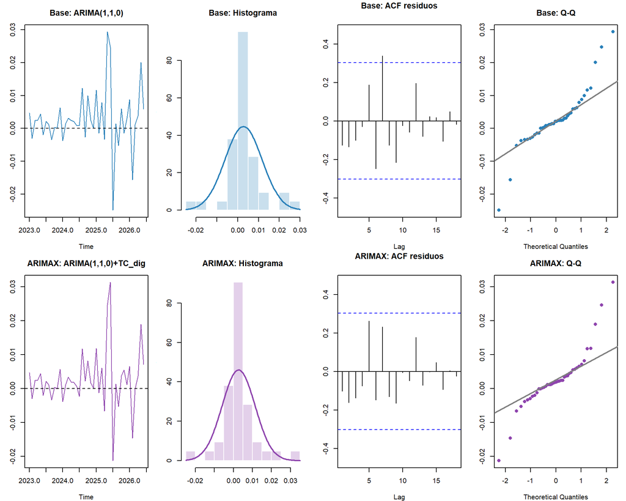

Autocorrelación residual — p-valores (H0: ruido blanco)

| Ljung-Box h | Base (p) | ARIMAX (p) |
| --- | --- | --- |
| 6 | 0.2228 | 0.1163 |
| 12 | 0.0599 | 0.1417 |
| 18 | 0.2484 | 0.4602 |

# 5 Backtesting

Se reservan los últimos 6 meses; ambos modelos se re-estiman solo con datos de entrenamiento y se comparan en **niveles de IPC**. Para el ARIMAX se usa el TC digital efectivamente observado en esos meses (backtest, no pronóstico real de la exógena). **Este es el criterio decisivo** — no el score dentro de muestra — para elegir el modelo final.

Backtesting — IPC observado vs. pronosticado

| Fecha | IPC obs. | Base pron. | ARIMAX pron. | Err. Base | Err. ARIMAX |
| --- | --- | --- | --- | --- | --- |
| ene 2026 | 149.06 | 147.77 | 148.02 | -1.29 | -1.04 |
| feb 2026 | 148.14 | 148.23 | 148.54 | 0.10 | 0.40 |
| mar 2026 | 147.63 | 148.57 | 149.06 | 0.94 | 1.43 |
| abr 2026 | 147.84 | 148.82 | 149.46 | 0.99 | 1.63 |
| may 2026 | 150.98 | 149.00 | 149.88 | -1.98 | -1.10 |
| jun 2026 | 154.22 | 149.14 | 150.05 | -5.08 | -4.17 |

Métricas de backtesting comparadas

| Métrica | ARIMA base | ARIMAX |
| --- | --- | --- |
| RMSE (IPC) | 2.3555 | 2.0225 |
| MAPE (IPC %) | 1.14% | 1.08% |

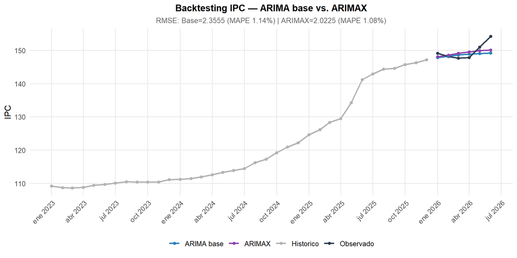

> **Modelo elegido: ARIMAX (+TC digital) (ARIMA(1,1,0)+TC_dig).** RMSE fuera de muestra: Base = 2.3555 vs ARIMAX = 2.0225 (MAPE: 1.14% vs 1.08%). El TC digital mejora la capacidad predictiva fuera de muestra, así que el pronóstico final usa el ARIMAX.

# 6 Pronóstico Final

## 6.1 Proyección comparada

Proyección de inflación — Base: ARIMA(1,1,0) vs ARIMAX: ARIMA(1,1,0)+TC_dig

| Mes | Base mensual (%) | Base interanual (%) | ARIMAX mensual (%) | ARIMAX interanual (%) |
| --- | --- | --- | --- | --- |
| Julio | 1.551 | 9.61 | 1.566 | 9.63 |
| Agosto | 1.123 | 9.74 | 1.136 | 9.77 |
| Septiembre | 0.814 | 10.41 | 0.824 | 10.45 |
| Octubre | 0.590 | 10.23 | 0.599 | 10.28 |
| Noviembre | 0.428 | 10.26 | 0.435 | 10.32 |
| Diciembre | 0.310 | 9.96 | 0.316 | 10.02 |
| Enero | 0.225 | 8.78 | 0.230 | 8.85 |

## 6.2 Fan chart — modelo elegido (ARIMAX (+TC digital))

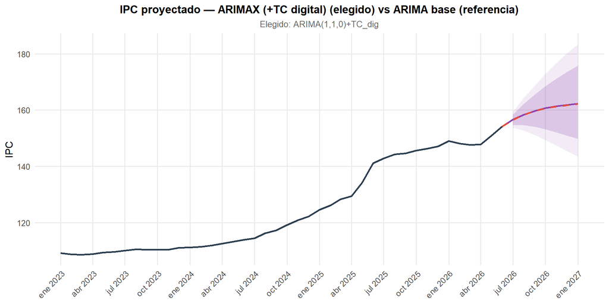

## 6.3 Inflación interanual — Base vs. ARIMAX

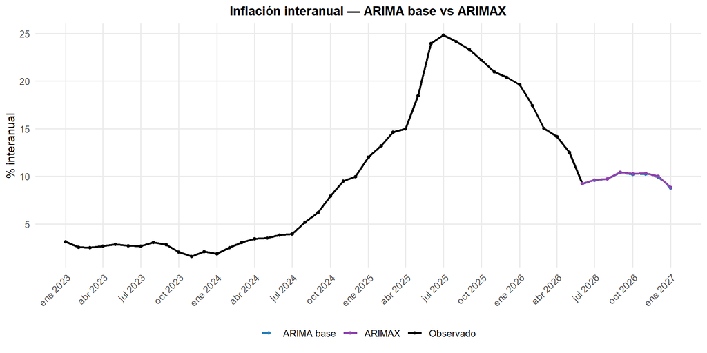

# 7 Escenario Contrafactual vs. Post-Bloqueos

Igual que en los otros reportes: se compara el pronóstico del modelo elegido (**ARIMAX (+TC digital)**) — sin disrupciones adicionales — contra el escenario que incorpora el efecto de los bloqueos de mayo 2025.

Contrafactual ARIMAX (+TC digital) vs. escenario post-bloqueos — Inflación interanual

| Mes | Mensual (%) | Interanual (%) — Contrafactual | Interanual (%) — Post-bloqueos | Diferencia (pp) |
| --- | --- | --- | --- | --- |
| Julio | 1.5657 | 9.63 | 10.12 | 0.49 |
| Agosto | 1.1358 | 9.77 | 10.54 | 0.78 |
| Septiembre | 0.8244 | 10.45 | 11.61 | 1.16 |
| Octubre | 0.5987 | 10.28 | 12.25 | 1.97 |
| Noviembre | 0.4349 | 10.32 | 13.05 | 2.73 |
| Diciembre | 0.3160 | 10.02 | 13.62 | 3.60 |

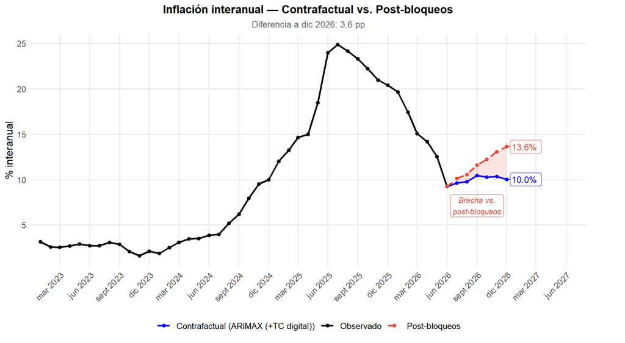

> A diciembre 2026, el escenario post-bloqueos proyecta una inflación interanual de **13.6%**, mientras que el contrafactual ARIMAX (+TC digital) estima **10%** — una diferencia de **3.6 puntos porcentuales**.

*Modelos estimados sobre log(IPC) desde 2023 (n=42). Regresor exógeno: TC digital mensualizado (interpolado antes de oct-2023).* *Scoring compuesto: RMSE + MAPE + (AICc + BIC + HQ)/3 + 0.3·Complejidad + penalizaciones LB y raíces — usado solo para elegir el mejor (p,d,q) dentro de cada familia.* *La elección entre ARIMA base y ARIMAX es por backtesting (fuera de muestra), no por score dentro de muestra: modelo final = **ARIMA(1,1,0)+TC_dig** (ARIMAX (+TC digital)).*